# Simulating TTE

# Set up

```r
setwd("~/Library/CloudStorage/OneDrive-UniversityofUtah/TTE_sims")
for (f in list.files("R", full.names = TRUE, pattern = "\\.R$")) source(f)
load("example_data.Rdata")
names(example_data)<-paste0("ASV", 1:ncol(example_data))
rownames(example_data)<-paste0("Person", 1:nrow(example_data))
```

```r
library(tidyverse)
library(survival)
library(simsurv)
library(pheatmap)
```

# Time to event simulation

The final function simulate_tte runs off a set of modularized functions.

1. Transform the data. Transforms the count matrix to a non-restricted space (no longer positive integers and no longer subject to the unit sum constraint). This transformed matrix can then be treated like a matrix of continuous predictors.
2. Create predictor value from linear or non-linear equations. This takes the transformed matrix and directions about which predictors should affect the outcome in which way and returns a single scalar value. This single scalar value is basically a risk score.
3. TTE design.

```
-   Option 1: Every gets a latent failure time.

-   Option 2: Mixture-cure model. This requires two scores, one for experiencing the event and one for when the event occurs.
```

4. Censoring. This can be administrative, random (according to some distribution), or both.

# Example data

We’re using data from a real example dataset I have. This is uncorrected data, and is not normalized, so the original library size is retained. There are 144 people and 1,731 ASV’s.

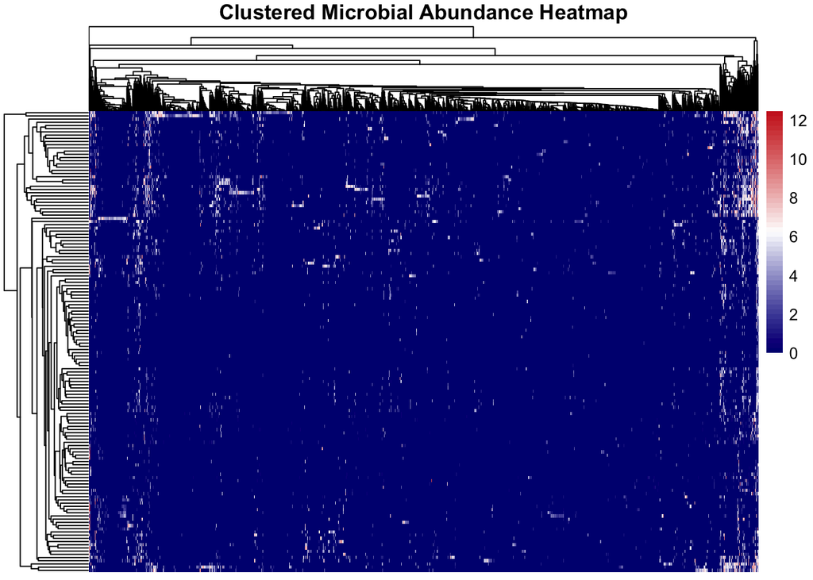

```r
matrix_data <- as.matrix(example_data)
log_matrix <- log1p(matrix_data)
pheatmap(
  mat = log_matrix,

  # Turn off the text to fix the issue in your image
  show_rownames = FALSE,
  show_colnames = FALSE,

  # Remove the borders around the cells (crucial for high-dimensional data)
  border_color = NA,

  # Cluster rows and columns so similar profiles group together
  cluster_rows = TRUE,
  cluster_cols = TRUE,

  # Define a color palette (viridis is great, or use this standard blue-white-red)
  color = colorRampPalette(c("navy", "white", "firebrick3"))(50),

  # Add a title
  main = "Clustered Microbial Abundance Heatmap"
)
```

# Step 1: Transformation

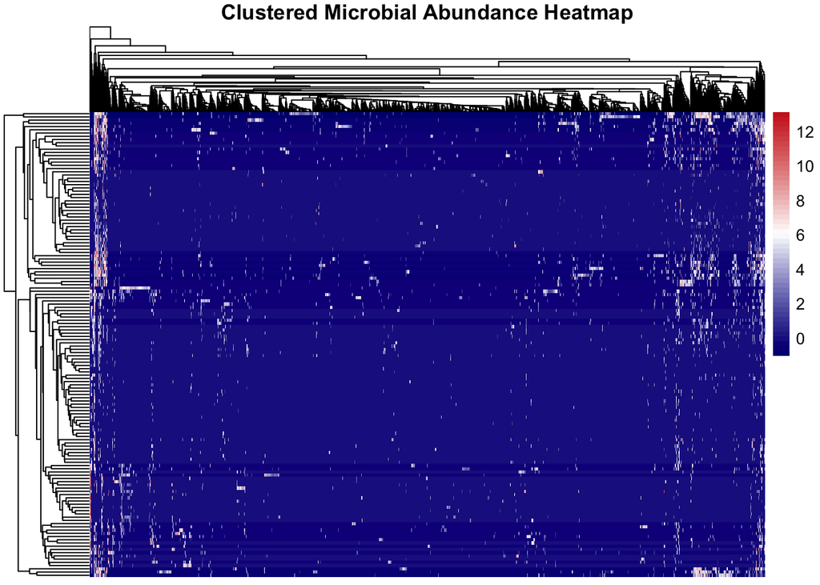

```r
transformed_matrix <- sim_transform(matrix_data)

pheatmap(
  mat = transformed_matrix,

  # Turn off the text to fix the issue in your image
  show_rownames = FALSE,
  show_colnames = FALSE,

  # Remove the borders around the cells (crucial for high-dimensional data)
  border_color = NA,

  # Cluster rows and columns so similar profiles group together
  cluster_rows = TRUE,
  cluster_cols = TRUE,

  # Define a color palette (viridis is great, or use this standard blue-white-red)
  color = colorRampPalette(c("navy", "white", "firebrick3"))(50),

  # Add a title
  main = "Clustered Microbial Abundance Heatmap"
)
```

# Step 2: Predictor value

Function takes in the matrix, the indices of the ‘active’ predictors, and either a vector of coefficients or a function.

## Option 1: Linear predictors

If you want simple linear predictors, you just need to supply beta coefficients. The vector of beta coefficients should be the same length as the vector of active predictors.

```r
# Pick 50 "active" ASVs and give each a positive coefficient.
active_idx <- 1:50
betas      <- rep(0.15, length(active_idx))

# One risk score (eta) per person.
eta_linear <- sim_predictor(transformed_matrix,
                            index = active_idx,
                            betas = betas)

str(eta_linear)
```

```
 num [1:144] 0.33452 -0.41361 1.03982 -0.30649 -0.00602 ...
```

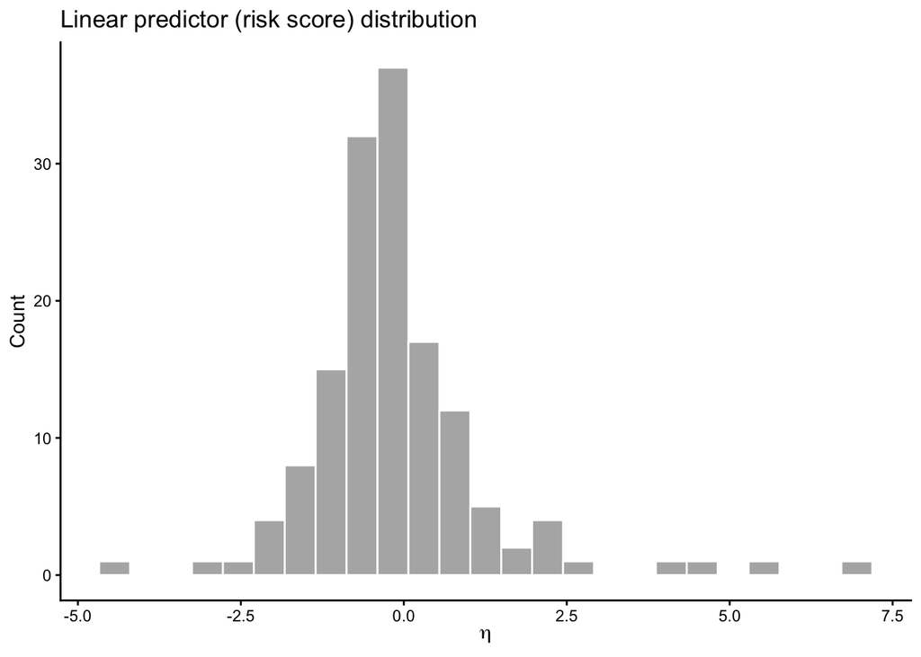

```r
ggplot(data.frame(eta = eta_linear), aes(x = eta)) +
  geom_histogram(bins = 25, fill = "grey70", color = "white") +
  labs(title = "Linear predictor (risk score) distribution",
       x = expression(eta), y = "Count") +
  theme_classic()
```

## Option 2: Custom function

If you want a more complex relationship, specify the function you want. Write it so that it takes in a vector of arguments, and then the active predictors will be used as the input to that function.

```r
# Each active predictor is passed as a positional argument to the function.
# Here: an interaction between ASV1 and ASV2 plus a nonlinear term on ASV3.
eta_custom <- sim_predictor(
  transformed_matrix,
  index = c(1, 2, 3),
  fn    = function(x1, x2, x3) 0.3 * x1 * x2 + sin(x3)
)

str(eta_custom)
```

```
 num [1:144] -0.1745 -0.0542 -0.1862 -0.0404 -0.0327 ...
```

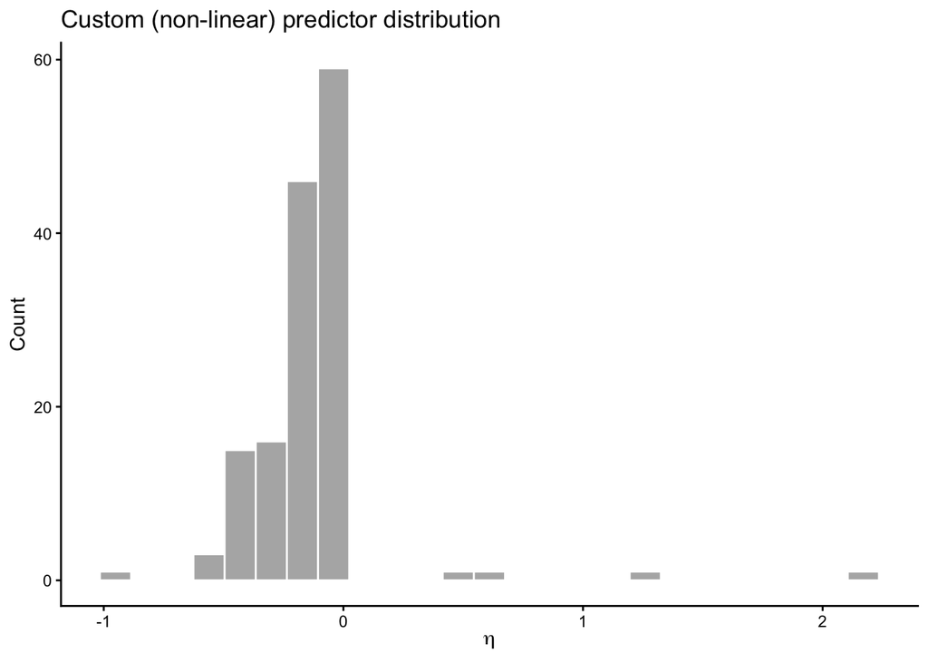

```r
ggplot(data.frame(eta = eta_custom), aes(x = eta)) +
  geom_histogram(bins = 25, fill = "grey70", color = "white") +
  labs(title = "Custom (non-linear) predictor distribution",
       x = expression(eta), y = "Count") +
  theme_classic()
```

## Mixture-cure model

If doing a mixture-cure model, the design is 2 stage. There is one risk score to calculate the risk of a person being at risk, and then one score to calculate the event time for the people at risk. I suggest using the same set of active predictors for both, but this is flexible.

```r
set.seed(7)

# Same active set drives both stages here (flexible — they can differ).
cure_idx <- 51:70

# Occurrence score (logit scale): governs who is susceptible / at risk.
eta_occurrence <- sim_predictor(transformed_matrix,
                                index = cure_idx,
                                betas = rnorm(length(cure_idx), 0, 0.8))

# Timing score: governs the failure time among the susceptible.
eta_timing <- sim_predictor(transformed_matrix,
                            index = cure_idx,
                            betas = rep(-0.2, length(cure_idx)))

# sim_tte turns the occurrence score into a person-specific susceptibility
# probability pi_i = plogis(a + eta_occurrence); the intercept a is solved
# internally to hit the target at-risk proportion.
head(data.frame(eta_occurrence = eta_occurrence, eta_timing = eta_timing))
```

```
  eta_occurrence eta_timing
1     -3.6830562  0.1349633
2     -0.3911079  0.2205928
3     -1.4148588  0.7980093
4     -0.2898106  0.1634591
5     -0.2339698  0.1319637
6     -0.9063020  0.5111729
```

# Step 3: Time to event

## Latent failure

In this type of model, every person gets a latent failure time. It is parametric, based on the predictor score. It can be either proportional hazards or AFT based.

### Weibull PH example:

Parameterization of the weibull model based off of the weibull distribution with shape parameter $\gamma > 0$ and scale/rate parameter $\lambda > 0$ . Shape controls whether the hazard increases or decreases with time. As $\lambda$ increases, the hazard increases, and survival is shorter.

Weibull proportional hazards relationships.

Baseline hazard function

$$h_0(t) = \gamma\lambda t^{\gamma-1}$$

Baseline cumulative hazard function

$$H_0(t) = \int_0^t h_0(s) ds \\
= \lambda \int_0^t \gamma s^{\gamma-1} ds\\
= \lambda t^{\gamma}\\
= -\log(S_0(t))$$

Baseline survival function

$$S_0(t) = \exp(-H_0(t)) \\
= \exp(-\lambda t^{\gamma})\\
= 1 - F_0(t)$$

Baseline probability density function

$$f_0(t) = S_0(t) h_0(t)\\
= \exp(-\lambda t^{\gamma})\gamma\lambda t^{\gamma-1}\\
= -\frac{d}{dt}S_0(t)\\
= \frac{d}{dt}F_0(t)$$

Baseline cumulative incidence function

$$F_0(t) = 1- S_0(t) \\
= 1 - \exp(-\lambda t^{\gamma})$$

This cumulative incidence function is a weibull CDF.

With linear predictors given by $\eta_i = x_i^T \beta$, the person specific functions are

Person specific hazard function

$$h_i(t) = h_0(t) \exp(\eta_i) \\
=\gamma\lambda t^{\gamma-1} \exp(\eta_i)$$

Person specific cumulative hazard function

$$H_i(t) = \int_0^t h_i(s) ds \\
= \lambda \exp(\eta_i) \int_0^t \gamma s^{\gamma-1} ds\\
= \lambda t^{\gamma} \exp(\eta_i)\\
= -\log(S_it))$$

Person specific survival function

$$S_i(t) = \exp(-H_i(t)) \\
= \exp(-\lambda t^{\gamma}\exp(\eta_i))\\
= 1 - F_i(t)$$

Person specific density function

$$f_i(t) = S_i(t) h_i(t)\\
= \exp(-\lambda t^{\gamma}\exp(\eta_i))\gamma\lambda t^{\gamma-1}\exp(\eta_i)\\
= -\frac{d}{dt}S_i(t)\\
= \frac{d}{dt}F_i(t)$$

Person specific cumulative distribution function

$$F_i(t) = 1- S_i(t) \\
= 1 - \exp(-\lambda t^{\gamma}\exp(\eta_i))$$

Consider $\eta \sim N(0, \sigma^2)$ to be a random pull. Then $\exp(\eta) \sim$ lognormal. This means that only the **conditional** event time $T_i | \eta_i$ is weibull ditributed.

Generic value of gamma: gamma = 1

- Constant hazard: 1
- Moderately increasing hazard: [1.2, 1]
- Decreasing hazard due to early risk: < 1

#### Scale of weibull should correlate with desired median survival time

- Choose a median survival time $m$ so that we can solve for

  $$m:= arg{ S_0(m) = 0.5}\\
  \exp(-\lambda m^{\gamma}) = 0.5 \\
  \lambda = -\frac{log 0.5}{m ^{\gamma}}$$
- Choose a baseline event probability $p$ at a certain time $\tau$

  $$p:= Pr(T_{event} \leq \tau) = 1 - S_0(\tau) \\
  S_0(\tau) = 1-p\\
  \exp(-\lambda \tau ^ {\gamma}) = 1-p \\
  \lambda = \frac{-\log(1-p)}{\tau^{\gamma}}$$

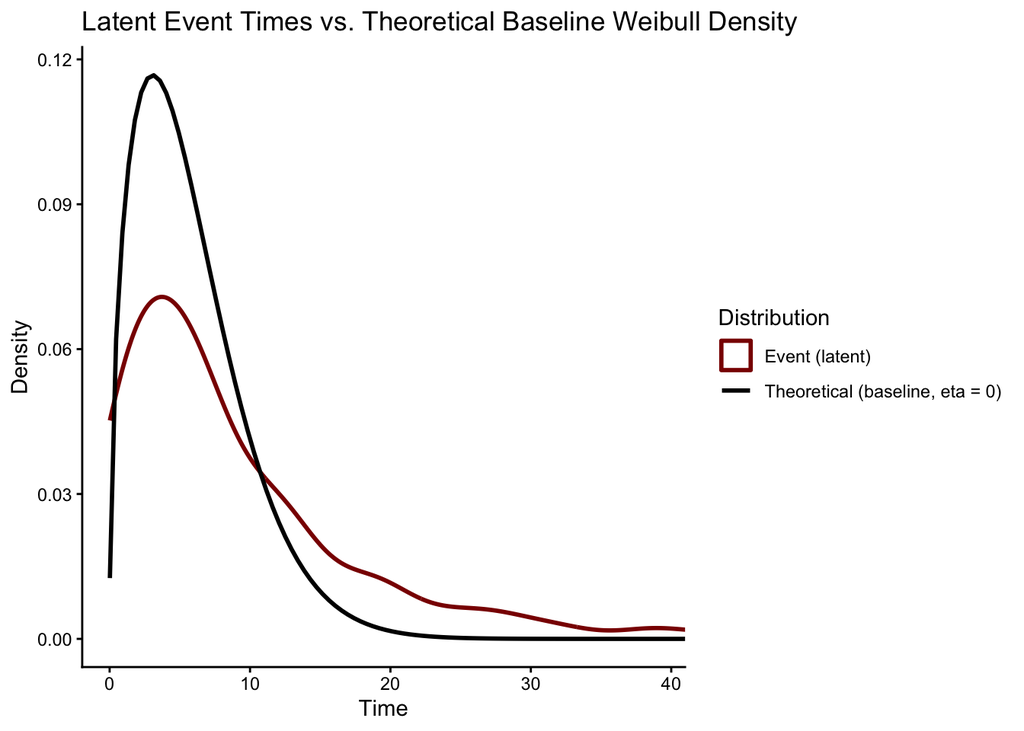

```r
set.seed(42)

# Timing predictor: reuse the linear risk score from Step 2.
eta_timing_ex <- sim_predictor(transformed_matrix,
                               index = 1:50,
                               betas = rep(0.15, 50))

# Draw latent failure times: Weibull PH, shape 1.5, baseline median 5.
tte_ph <- sim_tte(
  eta_timing    = eta_timing_ex,
  design        = "1stage",
  model         = "ph",
  dist          = "weibull",
  params        = list(shape = 1.5),
  target_median = 5
)

# Latent failure time for the (single) event — adapted from the 2-event
# diagnostic down to one event.
df_event <- data.frame(id     = tte_ph$id,
                       time   = tte_ph$latent_time,
                       status = 1)

# Theoretical BASELINE (eta = 0) Weibull density from the calibrated params.
# simsurv uses H0(t) = lambda * t^shape, so R's dweibull scale = lambda^(-1/shape)
# (this reduces to 1/lambda when shape = 1).
wb_shape <- tte_ph$shape
wb_scale <- tte_ph$lambda^(-1 / wb_shape)

# Note: because eta varies across people, the *marginal* latent density is a
# mixture (exp(eta) is lognormal) and only the *conditional* time T | eta is
# exactly Weibull — see the note above. The baseline curve is a face-validity
# reference, not an exact fit to the marginal.
ggplot(df_event, aes(x = time)) +
  geom_density(aes(color = "Event (latent)"), linewidth = 1) +
  stat_function(fun  = dweibull,
                args = list(shape = wb_shape, scale = wb_scale),
                aes(color = "Theoretical (baseline, eta = 0)"),
                linewidth = 1) +
  scale_color_manual(
    name   = "Distribution",
    values = c("Event (latent)"                 = "darkred",
               "Theoretical (baseline, eta = 0)" = "black")
  ) +
  coord_cartesian(xlim = c(0, quantile(df_event$time, 0.99))) +
  labs(title = "Latent Event Times vs. Theoretical Baseline Weibull Density",
       x = "Time", y = "Density") +
  theme_classic()
```

## Mixture-Cure

Here instead of giving everyone a failure time, we specify the people who are at risk. Traditionally we’d have the model as:

$$S(t) = (1-\pi) + \pi S_1(t)$$

We allow for the $\pi$ to be a function rather than a single value. This way you can determine who is at risk. If you want it to be random you can have the predictor function just be a constant.

# Step 4: Censoring

In the latent failure time, event rate is completely controlled by censoring. In the mixture-cure, event rate is controlled by a mix of the ‘at risk’ function ( $\pi$) as well as censoring.

## Administrative

Administrative censoring can be chosen by a specific value of desired censoring time, or by a target event rate.

## Random

Random censoring requires a distribution. Currently we have implemented an exponential censoring rate. For proportional hazards assumptions to hold, censoring should be non-informative and not related to any of the predictors.

# Full examples

## Latent time weibull ph

```r
set.seed(42)
betas_1 <- rep(0.15, 50)

res1 <- simulate_tte(
  counts          = example_data,
  design          = "one_stage",
  transform_args  = list(method = "clr", pseudocount = 0.5),
  predictor_args  = list(index = 1:50, betas = betas_1),
  tte_args        = list(model         = "ph",
                         dist          = "weibull",
                         params        = list(shape = 1.5),
                         target_median = 5),
  censor_args     = list(type = "administrative"),
  target_event_prop = 0.60,
  seed            = 42L
)

print(res1)
```

```
sim_tte_data  [n = 144 | p = 1731 | design = one_stage ]
  Events    : 87 / 144 (60.4 %)
  Median observed time : 6.171
```

## Mixture-cure weibull aft

```r
set.seed(7)
betas_occ    <- rnorm(20, mean = 0, sd = 0.8)
betas_timing <- rep(-0.2, 20)   # negative → shorter AFT survival

res2 <- simulate_tte(
  counts               = example_data,
  design               = "two_stage",
  transform_args       = list(method = "clr", pseudocount = 0.5),
  predictor_occurrence = list(index = 51:70,  betas = betas_occ),
  predictor_timing     = list(index = 71:90,  betas = betas_timing),
  tte_args             = list(model         = "aft",
                              dist          = "weibull",
                              params        = list(shape = 1.2),
                              target_median = 6),
  censor_args          = list(type                = "administrative_plus_random",
                              administrative_time = 15,
                              random              = list(dist = "exponential",
                                                         rate = 0.08)),
  target_event_prop    = 0.55,
  seed                 = 7L
)

print(res2)
```

```
sim_tte_data  [n = 144 | p = 1731 | design = two_stage ]
  Events    : 52 / 144 (36.1 %)
  Median observed time : 4.318
  Mean susceptibility pi: 0.55
```

```r
# Susceptibility check: π_i should vary and mean ≈ target_event_prop = 0.55
pi_mean <- mean(res2$tte$pi)
```

```r
res3 <- simulate_tte(
  counts          = example_data,
  design          = "one_stage",
  transform_args  = list(method = "clr"),
  predictor_args  = list(index = 1:2,
                         fn    = function(a, b) 0.3 * a - 0.3 * b),
  tte_args        = list(model         = "ph",
                         dist          = "exponential",
                         params        = list(shape = 1),
                         target_median = 4),
  censor_args     = list(type = "administrative"),
  target_event_prop = 0.65,
  seed            = 99L
)

print(res3)
```

```
sim_tte_data  [n = 144 | p = 1731 | design = one_stage ]
  Events    : 94 / 144 (65.3 %)
  Median observed time : 4.444
```